# European Covid Comparisons Part 2

This notebook continues the analysis I started in `european_covid_comparisons_1.Rmd`. In part 1 I wrangled the data and created a dataset of European countries’ populations and gdp per capita. Part 2 will supplement this dataset with data on Covid-19 testing and deaths.

Data on Covid deaths is taken from [World Health Organization Situation Reports](https://www.who.int/docs/default-source/coronaviruse/situation-reports/20200328-sitrep-68-covid-19.pdf?sfvrsn=384bc74c_2)

## Import and inspect the dataset

```r
library(dplyr)
library(readr)
library(stringr)

pop_and_gdp <-read_csv('european_pop_gdp_per_capita.csv')
pop_and_gdp
```

| X1 | Country | population | gdp_per_capita |
| --- | --- | --- | --- |
| 1 | Austria | 8950000 | 50022.612 |
| 2 | Belgium | 11458000 | 45175.585 |
| 3 | Bulgaria | 6960000 | 9518.437 |
| 4 | Croatia | 4060000 | 14949.759 |
| 5 | Cyprus | 876000 | 27719.690 |
| 6 | Czech Republic | 10638000 | 23213.954 |
| 7 | Denmark | 5806000 | 59795.269 |
| 8 | Estonia | 1319000 | 23523.596 |
| 9 | Finland | 5518000 | 48868.742 |
| 10 | France | 64824000 | 41760.606 |

[output cut: 20 more lines]

## import covid-19 data from WHO stats

Source: [Situation Report 68](https://www.who.int/docs/default-source/coronaviruse/situation-reports/20200328-sitrep-68-covid-19.pdf?sfvrsn=384bc74c_2), which collated data from national authorities submitted by 10:00 CET 28 March 2020.

```r
covid_deaths <- read_csv('european_covid_deaths_2020_28_mar.csv')
covid_deaths
```

| X1 | Country | deaths |
| --- | --- | --- |
| 1 | Austria | 68 |
| 2 | Belgium | 289 |
| 3 | Bulgaria | 3 |
| 4 | Croatia | 3 |
| 5 | Cyprus | 5 |
| 6 | Czech Republic | 9 |
| 7 | Denmark | 52 |
| 8 | Estonia | 1 |
| 9 | Finland | 7 |
| 10 | France | 1992 |

[output cut: 20 more lines]

## Import data on Covid-19 testing

This is going to be complicated. WHO does not produce statistics on this.

```r
covid_tests <- read_csv('european_covid_tests_2020_29_mar.csv')
covid_tests
```

| X1 | Country | tests |
| --- | --- | --- |
| 1 | Austria | 46441 |
| 2 | Belgium | 18360 |
| 3 | Bulgaria | 276 |
| 4 | Croatia | 1264 |
| 5 | Cyprus | Not known |
| 6 | Czech Republic | 40700 |
| 7 | Denmark | 20198 |
| 8 | Estonia | 2259 |
| 9 | Finland | 18000 |
| 10 | France | 101046 |

[output cut: 20 more lines]

## combine the datasets

```r
master <- pop_and_gdp %>% bind_cols(covid_deaths) %>% bind_cols(covid_tests)
master <- master %>% select(-Country1,-X11,-Country2,-X12)
master
```

| X1 | Country | population | gdp_per_capita | deaths | tests |
| --- | --- | --- | --- | --- | --- |
| 1 | Austria | 8950000 | 50022.612 | 68 | 46441 |
| 2 | Belgium | 11458000 | 45175.585 | 289 | 18360 |
| 3 | Bulgaria | 6960000 | 9518.437 | 3 | 276 |
| 4 | Croatia | 4060000 | 14949.759 | 3 | 1264 |
| 5 | Cyprus | 876000 | 27719.690 | 5 | Not known |
| 6 | Czech Republic | 10638000 | 23213.954 | 9 | 40700 |
| 7 | Denmark | 5806000 | 59795.269 | 52 | 20198 |
| 8 | Estonia | 1319000 | 23523.596 | 1 | 2259 |
| 9 | Finland | 5518000 | 48868.742 | 7 | 18000 |
| 10 | France | 64824000 | 41760.606 | 1992 | 101046 |

[output cut: 20 more lines]

## Sort the data

```r
sort_by_deaths <- master %>% arrange(desc(deaths))
sort_by_deaths
```

| X1 | Country | population | gdp_per_capita | deaths | tests |
| --- | --- | --- | --- | --- | --- |
| 16 | Italy | 60360000 | 32946.524 | 9136 | 429526 |
| 27 | Spain | 46656000 | 29961.105 | 4858 | 355000*as at 21 March |
| 10 | France | 64824000 | 41760.606 | 1992 | 101046 |
| 30 | United Kingdom | 66867000 | 41030.232 | 759 | 127737 |
| 21 | Netherlands | 17231000 | 52367.849 | 546 | 46810 |
| 11 | Germany | 82969000 | 46563.989 | 325 | 483295 |
| 2 | Belgium | 11458000 | 45175.585 | 289 | 18360 |
| 29 | Switzerland | 8545000 | 83716.813 | 197 | 111000 |
| 28 | Sweden | 10322000 | 51241.914 | 92 | 24500*as at 25 March |
| 24 | Portugal | 10265000 | 23030.786 | 76 | 38042 |

[output cut: 20 more lines]

## Visualise the data

### a. Is there a correlation between GPD and testing?

```r
library(ggplot2)
library(scales)
change_ireland <- master %>% mutate(tests=replace(as.numeric(tests), X1==c(15), c(17992)))
```

```
NAs introduced by coercion
```

```r
change_spain <- change_ireland %>% mutate(tests=replace(as.numeric(tests), X1==c(27), c(355000)))
change_sweden <- change_spain %>% mutate(tests=replace(as.numeric(tests), X1==c(28), c(24500)))
numerics <- change_sweden %>% filter(tests!="not known")
numerics
```

| X1 | Country | population | gdp_per_capita | deaths | tests |
| --- | --- | --- | --- | --- | --- |
| 1 | Austria | 8950000 | 50022.612 | 68 | 46441 |
| 2 | Belgium | 11458000 | 45175.585 | 289 | 18360 |
| 3 | Bulgaria | 6960000 | 9518.437 | 3 | 276 |
| 4 | Croatia | 4060000 | 14949.759 | 3 | 1264 |
| 6 | Czech Republic | 10638000 | 23213.954 | 9 | 40700 |
| 7 | Denmark | 5806000 | 59795.269 | 52 | 20198 |
| 8 | Estonia | 1319000 | 23523.596 | 1 | 2259 |
| 9 | Finland | 5518000 | 48868.742 | 7 | 18000 |
| 10 | France | 64824000 | 41760.606 | 1992 | 101046 |
| 11 | Germany | 82969000 | 46563.989 | 325 | 483295 |

[output cut: 17 more lines]

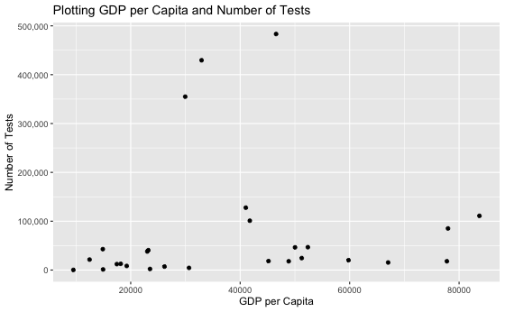

```r
#gdp_to_tests <- ggplot(master, aes(x=gdp_per_capita, y=tests)) + geom_line()
#gdp_to_tests

gdp_to_tests <- ggplot(numerics,aes(x=gdp_per_capita)) + geom_point(aes(y=tests)) +  scale_y_continuous(labels=label_comma()) + labs(title="Plotting GDP per Capita and Number of Tests", x="GDP per Capita", y="Number of Tests")

 gdp_to_tests
```

```r
NA
NA
```

### b. Is there a correlation between testing and deaths?

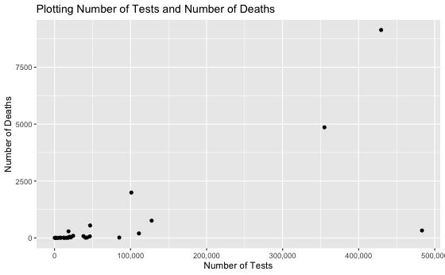

```r
tests_deaths <- ggplot(numerics,aes(x=tests)) + geom_point(aes(y=deaths)) + scale_x_continuous(labels=label_comma()) + labs(title="Plotting Number of Tests and Number of Deaths", x="Number of Tests", y="Number of Deaths")

tests_deaths
```

### c. Is there a correlation between GDP and deaths?

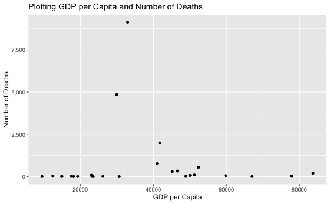

```r
gdp_to_deaths <- ggplot(numerics,aes(x=gdp_per_capita)) + geom_point(aes(y=deaths)) +  scale_y_continuous(labels=label_comma()) + labs(title="Plotting GDP per Capita and Number of Deaths", x="GDP per Capita", y="Number of Deaths")

 gdp_to_deaths
```

## Using rates for measuring deaths and tests

Given the differences in population size, it could be misleading to compare the raw numbers of tests and deaths. It is expected that- other things being equal - larger populations will require more testing than smaller populations. So, I will calculate the per capita testing and death rates. Note these are linked to each country’s total population, not the number of infected people.

```r
# add percent_tested
# This is the percentage of the population that has been tested.
#master <- master %>% mutate(tests=as.numeric(tests))

results_by_tests <- numerics %>% mutate(percent_tested=(tests/population)*100)
results_by_tests <- results_by_tests %>% mutate(percent_tested=format(percent_tested, digits=1))
results_by_tests <- results_by_tests %>% arrange(desc(percent_tested))
results_by_tests <- results_by_tests %>% mutate(percent_tested=as.numeric(percent_tested))
results_by_tests
```

| X1 | Country | population | gdp_per_capita | deaths | tests | percent_tested |
| --- | --- | --- | --- | --- | --- | --- |
| 14 | Iceland | 357000 | 67037.340 | 2 | 15484 | 4.337 |
| 22 | Norway | 5356000 | 77975.429 | 16 | 85163 | 1.590 |
| 29 | Switzerland | 8545000 | 83716.813 | 197 | 111000 | 1.299 |
| 20 | Malta | 485000 | 30650.168 | 0 | 4462 | 0.920 |
| 27 | Spain | 46656000 | 29961.105 | 4858 | 355000 | 0.761 |
| 16 | Italy | 60360000 | 32946.524 | 9136 | 429526 | 0.712 |
| 17 | Latvia | 1929000 | 18171.651 | 0 | 12748 | 0.661 |
| 11 | Germany | 82969000 | 46563.989 | 325 | 483295 | 0.583 |
| 1 | Austria | 8950000 | 50022.612 | 68 | 46441 | 0.519 |
| 6 | Czech Republic | 10638000 | 23213.954 | 9 | 40700 | 0.383 |

[output cut: 17 more lines]

```r
NA
```

## Is there a correlation between gpd_per_capita and tests_per_capita?

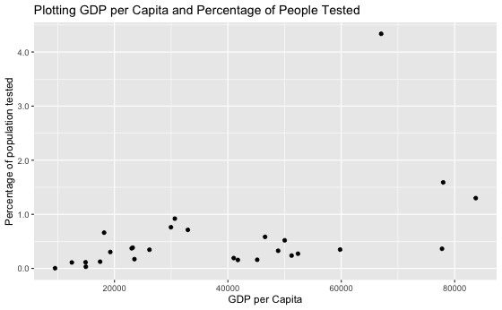

```r
gdp_to_tests_per_capita <- ggplot(results_by_tests,aes(x=gdp_per_capita)) + geom_point(aes(y=percent_tested)) +  scale_y_continuous(labels=label_comma()) + labs(title="Plotting GDP per Capita and Percentage of People Tested", x="GDP per Capita", y="Percentage of population tested")
gdp_to_tests_per_capita
```

```r
# add risk of death (%)
results_by_deaths <- results_by_tests %>% mutate(death_risk=(deaths/population)*100)
results_by_deaths <- results_by_deaths %>% mutate(death_risk=format(death_risk, digits=2, scientific=FALSE))
results_by_deaths <- results_by_deaths %>% arrange(desc(death_risk))
results_by_deaths <- results_by_deaths %>% mutate(death_risk=as.numeric(death_risk))
results_by_deaths
```

| X1 | Country | population | gdp_per_capita | deaths | tests | percent_tested | death_risk |
| --- | --- | --- | --- | --- | --- | --- | --- |
| 16 | Italy | 60360000 | 32946.524 | 9136 | 429526 | 0.712 | 0.015136 |
| 27 | Spain | 46656000 | 29961.105 | 4858 | 355000 | 0.761 | 0.010412 |
| 21 | Netherlands | 17231000 | 52367.849 | 546 | 46810 | 0.272 | 0.003169 |
| 10 | France | 64824000 | 41760.606 | 1992 | 101046 | 0.156 | 0.003073 |
| 2 | Belgium | 11458000 | 45175.585 | 289 | 18360 | 0.160 | 0.002522 |
| 29 | Switzerland | 8545000 | 83716.813 | 197 | 111000 | 1.299 | 0.002305 |
| 30 | United Kingdom | 66867000 | 41030.232 | 759 | 127737 | 0.191 | 0.001135 |
| 7 | Denmark | 5806000 | 59795.269 | 52 | 20198 | 0.348 | 0.000896 |
| 28 | Sweden | 10322000 | 51241.914 | 92 | 24500 | 0.237 | 0.000891 |
| 1 | Austria | 8950000 | 50022.612 | 68 | 46441 | 0.519 | 0.000760 |

[output cut: 17 more lines]

```r
# I learned how to format a number with scientific=FALSE - this trnasformed a number 9.0e-04 into something I can understand (0.015136)
```

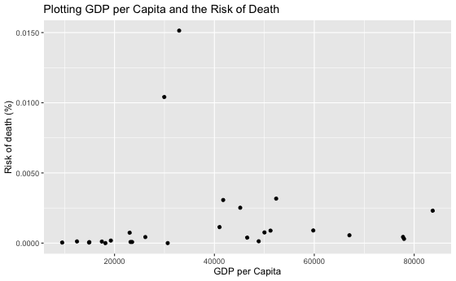

```r
gdp_to_death_risk <- ggplot(results_by_deaths,aes(x=gdp_per_capita)) + geom_point(aes(y=death_risk)) +  scale_y_continuous(labels=label_comma()) + labs(title="Plotting GDP per Capita and the Risk of Death", x="GDP per Capita", y="Risk of death (%)")
gdp_to_death_risk
```

```r
# Work out the natural frequency in a thousand. E.g. 3 people in every thousand will get a test.
# define the function
frequency_in_a_thousand <- function(risk) {(risk/100)*1000}
# plug in some numbers

#all_frequencies <- function() {
#for (row in 1:nrow(results_by_deaths)) {
#freq <- frequency_in_a_thousand(results_by_deaths[row, "death_risk"])
#country <- results_by_deaths[row, "Country"]
#speech <- str_glue("In {country}, {freq} people in every thousand have died of the virus.")
#print(speech)}
#  return()
#}

#bob <- all_frequencies()
#bob
# so, this function works, but it adds an unwanted NULL line. I'll try it without the wrapper function.

for (row in 1:nrow(results_by_deaths)) {
freq <- frequency_in_a_thousand(results_by_deaths[row, "death_risk"])
country <- results_by_deaths[row, "Country"]
speech <- str_glue("In {country}, {freq} people in every thousand have died of the virus.")
print(speech)}
```

```
In Italy, 0.15136 people in every thousand have died of the virus.
In Spain, 0.10412 people in every thousand have died of the virus.
In Netherlands, 0.03169 people in every thousand have died of the virus.
In France, 0.03073 people in every thousand have died of the virus.
In Belgium, 0.02522 people in every thousand have died of the virus.
In Switzerland, 0.02305 people in every thousand have died of the virus.
In United Kingdom, 0.01135 people in every thousand have died of the virus.
In Denmark, 0.00896 people in every thousand have died of the virus.
In Sweden, 0.00891 people in every thousand have died of the virus.
In Austria, 0.0076 people in every thousand have died of the virus.
In Portugal, 0.0074 people in every thousand have died of the virus.
In Iceland, 0.0056 people in every thousand have died of the virus.
In Ireland, 0.00444 people in every thousand have died of the virus.
In Slovenia, 0.00435 people in every thousand have died of the virus.
In Germany, 0.00392 people in every thousand have died of the virus.
In Norway, 0.00299 people in every thousand have died of the virus.
In Lithuania, 0.0018 people in every thousand have died of the virus.
In Finland, 0.00127 people in every thousand have died of the virus.
In Romania, 0.00123 people in every thousand have died of the virus.
In Hungary, 0.00113 people in every thousand have died of the virus.
In Czech Republic, 0.00085 people in every thousand have died of the virus.
In Estonia, 0.00076 people in every thousand have died of the virus.
In Croatia, 0.00074 people in every thousand have died of the virus.
In Bulgaria, 0.00043 people in every thousand have died of the virus.
In Poland, 0.00042 people in every thousand have died of the virus.
In Malta, 0 people in every thousand have died of the virus.
In Latvia, 0 people in every thousand have died of the virus.
```

```r
#Note a problem with the frequency of Czech Republic, Croatia, Poland and Bulgaria. The format is "8e-04". To fix this
```

## Express the frequency as a “1 in XXXX” chance

```r
frequency <- function(population, deaths) {
  return(population/deaths)
}

#for (row in 1:nrow(results_by_deaths)) {
#freq <- frequency(results_by_deaths[row, "population"], results_by_deaths[row, "deaths"])
#freq <- format(freq, big.mark = ",", digits=0, scientific = FALSE)
#country <- results_by_deaths[row, "Country"]
#speech <- str_glue("In {country}, 1 person in  {freq} has died of the virus.")
#print(speech)}

# Note that the for loop doesn't work for countries with zero deaths. It says that 1 person in Inf has died. Solution is to add an if statement to exclude
for (row in 1:nrow(results_by_deaths)) {
  country <- results_by_deaths[row, "Country"]
  if (results_by_deaths[row, "deaths"] > 0) {
freq <- frequency(results_by_deaths[row, "population"], results_by_deaths[row, "deaths"])
freq <- format(freq, big.mark = ",", digits=0, scientific = FALSE)

speech <- str_glue("In {country}, 1 person in  {freq} has died of the virus.")
print(speech)}
  else {
    nil_speech <- str_glue("No one has died in {country} yet, so no frequency can be determined.")
    print(nil_speech)
  }
}
```

```
In Italy, 1 person in  6,607 has died of the virus.
In Spain, 1 person in  9,604 has died of the virus.
In Netherlands, 1 person in  31,559 has died of the virus.
In France, 1 person in  32,542 has died of the virus.
In Belgium, 1 person in  39,647 has died of the virus.
In Switzerland, 1 person in  43,376 has died of the virus.
In United Kingdom, 1 person in  88,099 has died of the virus.
In Denmark, 1 person in  111,654 has died of the virus.
In Sweden, 1 person in  112,196 has died of the virus.
In Austria, 1 person in  131,618 has died of the virus.
In Portugal, 1 person in  135,066 has died of the virus.
In Iceland, 1 person in  178,500 has died of the virus.
In Ireland, 1 person in  225,000 has died of the virus.
In Slovenia, 1 person in  229,889 has died of the virus.
In Germany, 1 person in  255,289 has died of the virus.
In Norway, 1 person in  334,750 has died of the virus.
In Lithuania, 1 person in  556,800 has died of the virus.
In Finland, 1 person in  788,286 has died of the virus.
In Romania, 1 person in  813,417 has died of the virus.
In Hungary, 1 person in  887,091 has died of the virus.
In Czech Republic, 1 person in  1,182,000 has died of the virus.
In Estonia, 1 person in  1,319,000 has died of the virus.
In Croatia, 1 person in  1,353,333 has died of the virus.
In Bulgaria, 1 person in  2,320,000 has died of the virus.
In Poland, 1 person in  2,373,312 has died of the virus.
No one has died in Malta yet, so no frequency can be determined.
No one has died in Latvia yet, so no frequency can be determined.
```

```r
# I learned how to format the numbers with commas, using big.mark
```

# Sources

Where possible, data have been taken from official government websites. Where this was not possible, I have used a [Wikipedia page on Covid-19 testing](https://en.wikipedia.org/wiki/COVID-19_testing).

Austria

[Bulgaria: Wikipedia page](https://en.wikipedia.org/wiki/2020_coronavirus_pandemic_in_Bulgaria) [Cyprus](https://www.pio.gov.cy/coronavirus/en/index.html) [Hungary](https://koronavirus.gov.hu/) [Iceland](https://www.covid.is/tolulegar-upplysingar) [Lithuania](http://sam.lrv.lt/lt/naujienos/koronavirusas) [Norway](https://www.fhi.no/en/id/infectious-diseases/coronavirus/daily-reports/daily-reports-COVID19/)

[Romania](https://www.mai.gov.ro/informare-covid-19-grupul-de-comunicare-strategica-29-martie-ora-13-00/)

[Slovenia](https://www.korona.gov.sk/)

[Sweden](https://www.folkhalsomyndigheten.se/smittskydd-beredskap/utbrott/aktuella-utbrott/covid-19/aktuellt-epidemiologiskt-lage/)